# Detección de anomalías: trimmed k-means

Joaquín Amat Rodrigo j.amatrodrigo@gmail.com

Abril, 2020

Más sobre ciencia de datos: cienciadedatos.net o [joaquinamatrodrigo.github.io](https://joaquinamatrodrigo.github.io/)

# Introducción

Los métodos de *clustering* son una de las estrategias no supervisadas que se emplean con frecuencia para la detección de anomalías (*outliers*). Estos algoritmos tratan de identificar regiones homogéneas separadas entre ellas por regiones heterogéneas, agrupando las observaciones de forma que, aquellas que forman parte del mismo *cluster*, son similares entre ellas y distintas a las de otros *clusters*.

Para que un método de *clustering* pueda emplearse como detector de anomalías, idealmente debe cumplir alguna de estas dos características:

- No obligar a que todas las observaciones formen parte de uno de los *clusters*.
- Calcular la probabilidad que tiene cada observación de pertenecer a cada uno de los *clusters*.

En el primer caso, se consideran anomalías aquellas observaciones que no han sido asignadas a ningún *cluster*. En el segundo caso, aquellas cuya probabilidad de pertenecer a alguno de los *clusters* está por debajo de un valor mínimo.

El requisito de permitir dejar observaciones “libres” es consecuencia de que los métodos de *clustering* se vean muy influenciados por observaciones anómalas. Por ejemplo:

- Dos o más *clusters* pueden unirse de forma artificial debido únicamente a observaciones atípicas que se encuentran entre ellos.
- Se pueden crear *clusters* artificiales compuestos únicamente por unas pocas observaciones atípicas

Una forma de minimizar estos problemas es emplear adaptaciones robustas de los algoritmos. Por ejemplo, incorporando un proceso de *trimming* para eliminar una fracción $\alpha$ de los valores más extremos.

# Trimmed K-means

- `equal.weights`: si su valor es `TRUE`, el algoritmo trata de que todos los *clusters* tengan el mismo número de observaciones.
- `restr.fact`: controla el grado de restricción impuesta sobre el ajuste. Cuanto mayor es su valor, menor es la restricción y mayor es la heterogeneidad permitida en los *clusters* creados. Valores próximos a 1 generan *clusters* con una dispersión similar.
- `restr`: tipo de restricción impuesta a las matrices de covarianza de los *clusters*.
  - `"eigen"`: controla el ratio entre el mayor y menor eigenvalue de las matrices de covarianza. Este tipo de restricción controla el tamaño relativo de los ejes de los elipsoides que definen los *clusters*, es decir, cuánto se desvían respecto a una forma esférica.
  - `"deter"`: controla el ratio entre el mayor y menor determinante de las matriz de covarianzas. Este tipo de restricción controla el volumen relativo de los elipsoides que forman los *clusters* pero no su forma.
  - `"sigma"`: obliga a que la matriz de covarianza de todos los *clusters* sea la misma.

# Ejemplo

El set de datos `M5data`, disponible en el paquete `tclust`, contiene observaciones simuladas a partir de tres distribuciones gaussianas bivariante de distinta media y dispersión, dos de ellas con solapamiento. Además, se ha introducido un 10% de anomalías en la región que rodea a las componentes gaussianas Este set de datos es útil para evaluar la capacidad que tienen distintos algoritmos para detectar anomalías en entornos de pocas dimensiones.

```r
library(tidyverse)
library(tclust)
data("M5data")
datos <- as.data.frame(M5data)
head(datos)
```

|  | x | y | cluster |
| --- | --- | --- | --- |
| 1 | 0.4260915 | 9.231964 | 1 |
| 2 | 1.2965541 | 8.476324 | 1 |
| 3 | -0.6509459 | 8.601383 | 1 |
| 4 | -0.5649144 | 8.486292 | 1 |
| 5 | -0.7661360 | 9.009730 | 1 |
| 6 | -0.7480846 | 8.583560 | 1 |

La columna `cluster` contiene la asignación verdadera de cada observación. Aquellas observaciones con el valor cero se corresponden con anomalías.

```r
# Número de observaciones por cluster y anomalías
table(datos$cluster)
```

```
##
##   0   1   2   3
## 200 360 720 720
```

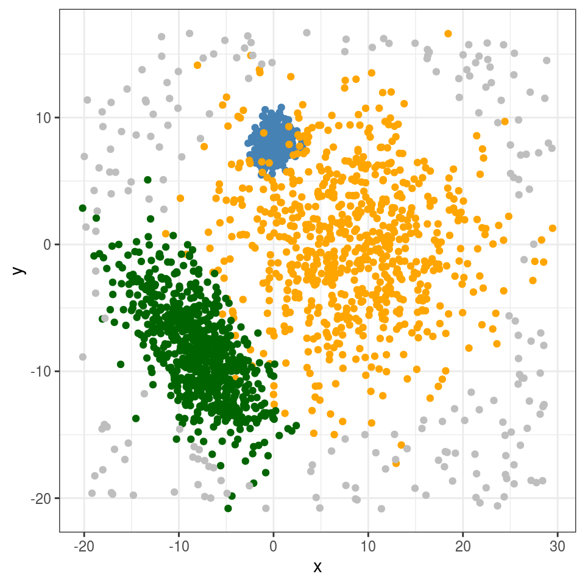

```r
ggplot(data = datos, aes(x = x, y = y, color = as.factor(cluster))) +
geom_point() +
theme_bw() +
scale_color_manual(
  breaks = c(0,1,2,3),
  values = c("0"="gray", "1"="steelblue", "2"="orange", "3"="darkgreen")
) +
theme(legend.position = "none")
```

Se aplica el algoritmo de clustering asumiendo que hay 3 componentes.

```r
clustering <- tclust(
                x = scale(datos[, 1:2], center = TRUE, scale = TRUE),
                k = 3,
                alpha = 0.1,
                restr = "eigen",
                restr.fact = 20,
                nstart = 50,
                iter.max = 1000
              )
clustering
```

```
## * Results for TCLUST algorithm: *
## trim = 0.1, k = 3
## Classification (trimmed points are indicated by 0 ):
##    [1] 3 3 3 3 3 3 3 3 3 3 3 3 3 3 3 3 3 3 3 3 3 3 3 3 3 3 3 3 3 3 3 3 3 3 3 3 3
##   [38] 3 3 3 3 3 3 3 3 3 3 3 3 3 3 3 3 3 3 3 3 3 3 3 3 3 3 3 3 3 3 3 3 3 3 3 3 3
##   [75] 3 3 3 3 3 3 3 3 3 3 3 3 3 3 3 3 3 3 3 3 3 3 3 3 3 3 3 3 3 3 3 3 3 3 3 3 3
##  [112] 3 3 3 3 3 3 3 3 3 3 3 3 3 3 3 3 3 3 3 3 3 3 3 3 3 3 3 3 3 3 3 3 3 3 3 3 3
##  [149] 3 3 3 3 3 3 3 3 3 3 3 3 3 3 3 3 3 3 3 3 3 3 3 3 3 3 3 3 3 3 3 3 3 3 3 3 3
##  [186] 3 3 3 3 3 3 3 3 3 3 3 3 3 3 3 3 3 3 3 3 3 3 3 3 3 3 3 3 3 3 3 3 3 3 3 3 3
##  [223] 3 3 3 3 3 3 3 3 3 3 3 3 3 3 3 3 3 3 3 3 3 3 3 3 3 3 3 3 3 3 3 3 3 3 3 3 3
##  [260] 3 3 3 3 3 3 3 3 3 3 3 3 3 3 3 3 3 3 3 3 3 3 3 3 3 3 3 3 3 3 3 3 3 3 3 3 3
##  [297] 3 3 3 3 3 3 3 3 3 3 3 3 3 3 3 3 3 3 3 3 3 3 3 3 3 3 3 3 3 3 3 3 3 3 3 3 3
##  [334] 3 3 3 3 3 3 3 3 3 3 3 3 3 3 3 3 3 3 3 3 3 3 3 3 3 3 3 2 2 2 2 2 2 2 2 2 2
##  [371] 2 2 2 2 2 2 2 2 2 2 2 2 2 2 2 2 1 2 2 2 2 2 2 2 2 2 2 2 2 2 2 2 2 2 2 2 2
##  [408] 2 2 2 2 2 2 2 2 2 3 2 2 2 2 1 2 2 2 2 2 2 2 2 2 2 1 3 2 2 2 2 2 2 2 2 2 1
```

[output cut: 50 more lines]

Las observaciones asignadas al *cluster* 0 son las que han sido excluidas. Se comprueba cuántas de ellas se corresponden con verdaderas anomalías (column `cluster` es igual a 0).

```r
datos$cluster_asignado <- as.factor(clustering$cluster)
head(datos)
```

|  | x | y | cluster | cluster_asignado |
| --- | --- | --- | --- | --- |
| 1 | 0.4260915 | 9.231964 | 1 | 3 |
| 2 | 1.2965541 | 8.476324 | 1 | 3 |
| 3 | -0.6509459 | 8.601383 | 1 | 3 |
| 4 | -0.5649144 | 8.486292 | 1 | 3 |
| 5 | -0.7661360 | 9.009730 | 1 | 3 |
| 6 | -0.7480846 | 8.583560 | 1 | 3 |

```r
# Número de observaciones identificadas como anomalías
sum(clustering$cluster == 0)
```

```
## [1] 200
```

```r
# Número de anomalías correctamente identificadas
sum(datos$cluster == 0 & datos$cluster_asignado == 0)
```

```
## [1] 175
```

```r
# Número observaciones eroneamente detectadas como anomalías.
sum(datos$cluster != 0 & datos$cluster_asignado == 0)
```

```
## [1] 25
```

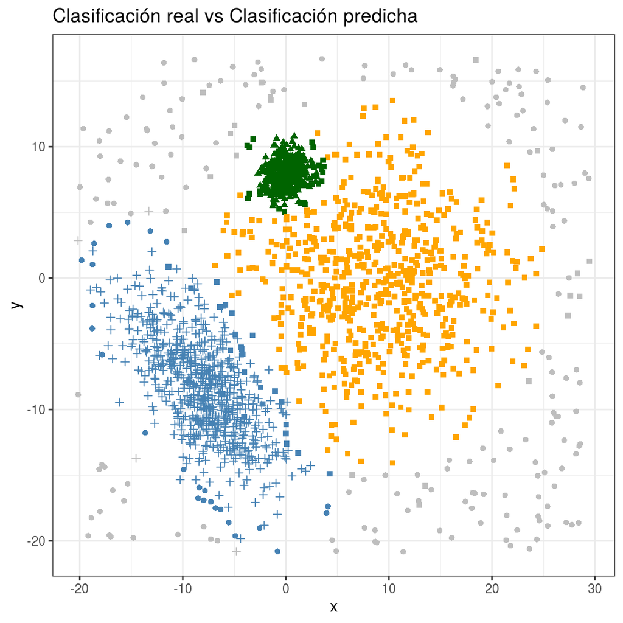

```r
ggplot(data = datos, aes(x = x, y = y,
       shape = as.factor(cluster), color = cluster_asignado)) +
geom_point() +
theme_bw() +
scale_color_manual(
  breaks = c(0, 1, 2, 3),
  values = c("0"="gray", "1"="steelblue", "2"="orange", "3"="darkgreen")
) +
labs(title = "Clasificación real vs Clasificación predicha") +
theme(legend.position = "none")
```

En la ejecución anterior, se asumió el número de componentes `k=3` y de *trimming* `alpha=0.1`, gracias a que se conoce cómo se han simulado los datos. En la práctica, esta información se desconoce y, al tratarse de un problema de aprendizaje no supervisado, no hay forma de saberlo con seguridad. Una estrategia que permite orientar en la selección de estos hiperparámetros es ver cómo varía el *likelihood* para diferentes valores de `k` y `alpha` e identificar el punto en el que el incremento se estabiliza. Este proceso se puede automatizar con la función `ctlcurves()`.

```r
grid_search <- ctlcurves(
                  x = scale(datos[, 1:2], center = TRUE, scale = TRUE),
                  k = 1:6,
                  alpha = seq(0, 0.5, 0.05),
                  restr = "eigen",
                  restr.fact = 12,
                  nstart = 50,
                  iter.max = 1000,
                  trace = 0
                )
```

```r
grid_search
```

```
## Computed 66 solutions (chosen restr.fact = 12).
##
##    alpha
## k   0 0.05 0.1 0.15 0.2 0.25 0.3 0.35 0.4 0.45 0.5
##   1                                       *    *
##   2   *                               *   *    *
##   3 * *    *   *    *   *    *   *    *   *    *
##   4 * *    *k  *k   *k  *    *   *    *k  *    *k
##   5 * *    *k  *k   *k  *    *k  *k   *   *k   *k
##   6 * *k   *k  *k   *k  *    *k  *k   *k  *k   *k
##
## (*) Identified 50 artificially restricted solutions.
## (k) Identified 21 solutions with very small/dropped clusters.
```

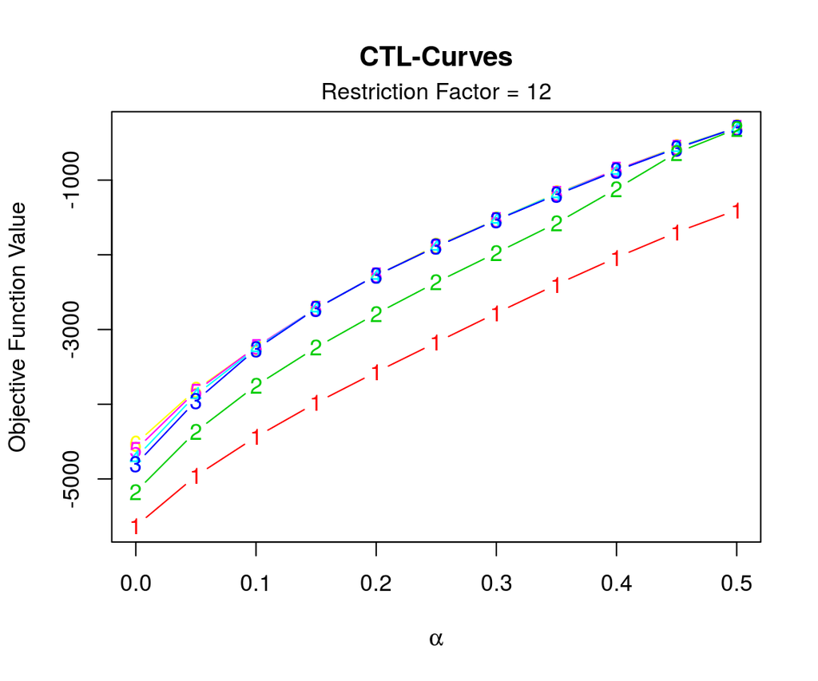

```r
plot(grid_search)
```

Acorde al gráfico, a partir de `k=3` no se consigue una mejora del ajuste. Para el valor de `alpha`, la mejora en el ajuste es casi constante, con un incremento ligeramente más marcado entorno a 0.5-0.1.

# Bibliografía

Charu C. Aggarwal. 2016. Outlier Analysis (2nd. ed.). Springer Publishing Company, Incorporated.

Fritz, Heinrich & García-Escudero, Luis & Mayo, Agustin. (2012). tclust: An R Package for a Trimming Approach to Cluster Analysis. Journal of Statistical Software. 47. 10.18637/jss.v047.i12.

This work by Joaquín Amat Rodrigo is licensed under a [Creative Commons Attribution 4.0 International License](http://creativecommons.org/licenses/by/4.0/).